# Lab3

# 3. Reproduce the plot using a color blind safe palette.

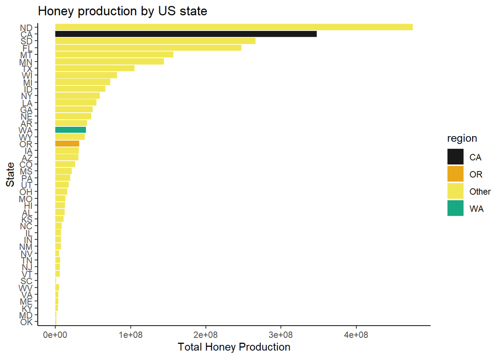

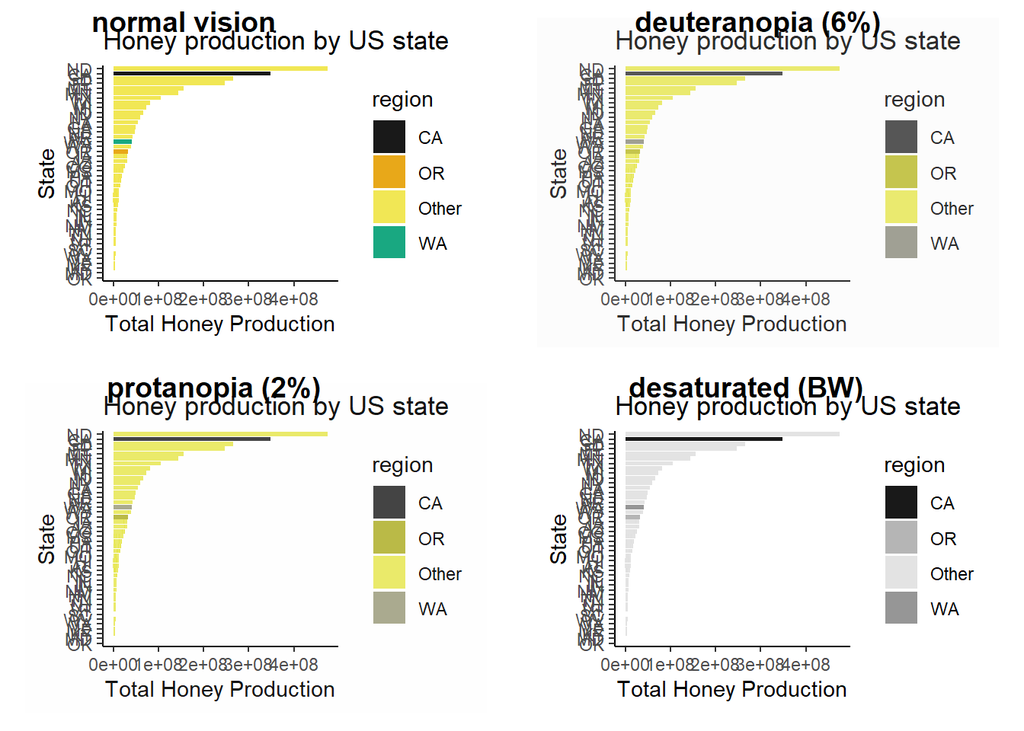

# 4. Download the file here denoting the region and division of each state.

- Join the file with your honey file
- Produce a bar plot displaying the average honey for each state (collapsing across years).
- Use color to highlight the region of the country the state is from.
- Note patterns you notice.

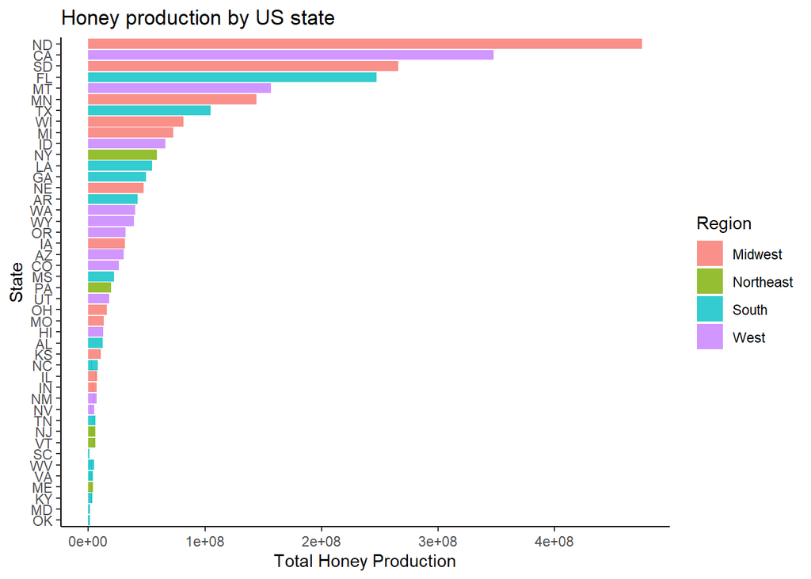

In terms of patterns, it seems as though the midwest and west produce the most honey, followed by the south, and the northeast producing the least honey.

# 5. Create a heatmap displaying the average honey production across years by region (averaging across states within region).

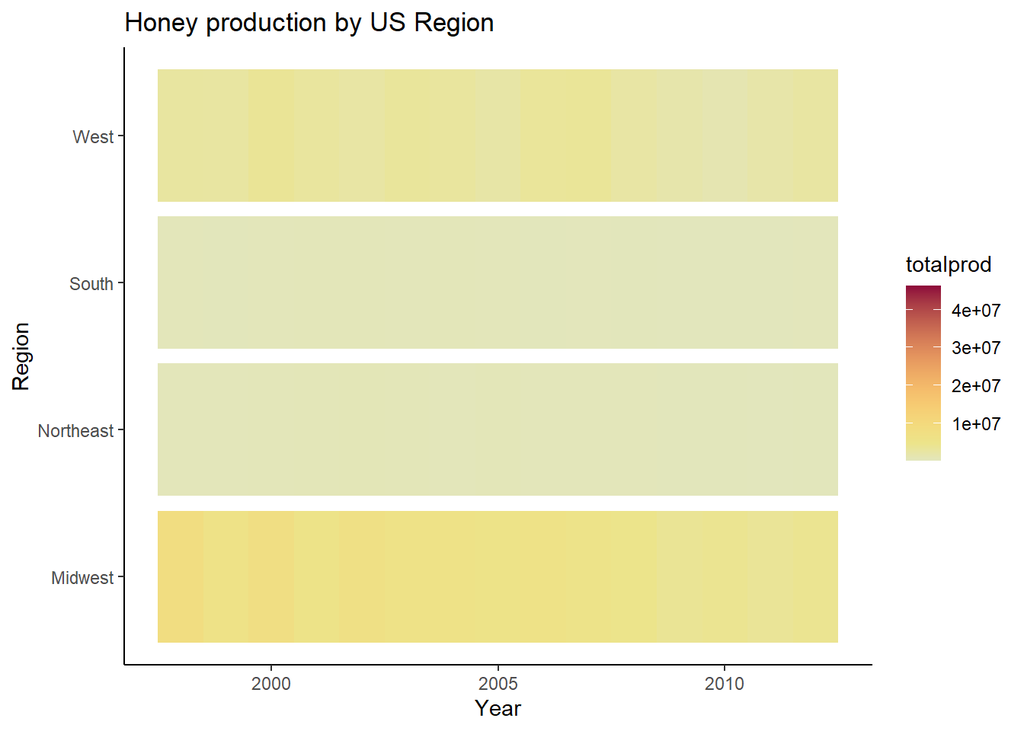

# 6. Create at least one more plot of your choosing using color to distinguish, represent data values, or highlight.

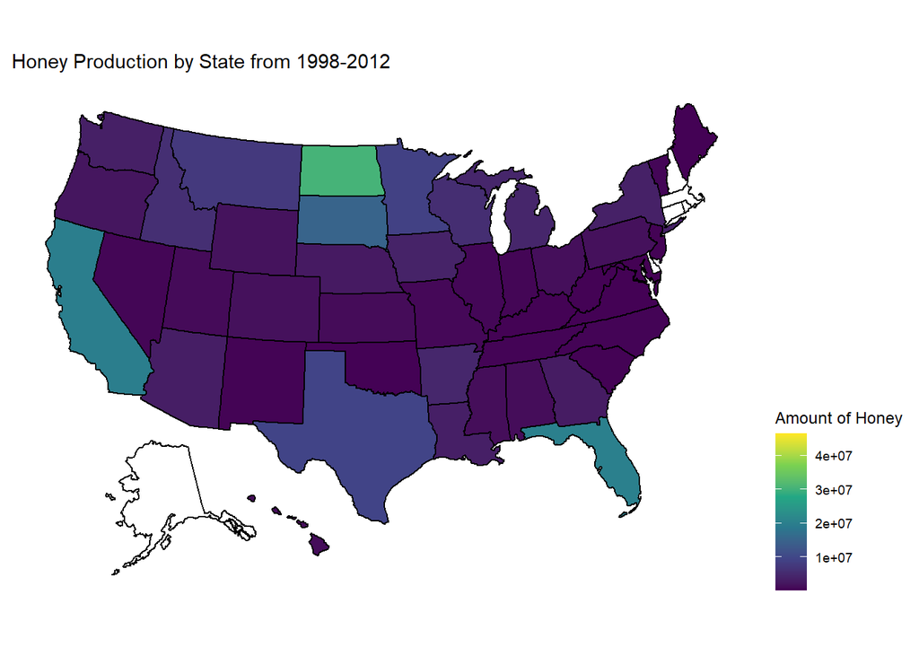